# Matching the Stock Synthesis configuration: Indian Ocean yellowfin

**Setup**

```r
library(opal)
library(ggplot2)

data(io_yft_data)
data(io_yft_parameters)
data(io_yft_map)
data(io_yft_reference)

ref  <- io_yft_reference
d    <- io_yft_data
n_ts <- d$n_year
sf   <- ref$ss3$sizefreq

# Model outputs precomputed by data-raw/generate-io-yft-vignette-cache.R
cache <- readRDS(system.file("extdata", "io_yft_vignette_cache.rds", package = "opal"))
m <- cache$models

fmt <- function(x, digits = 2) formatC(x, format = "f", digits = digits, big.mark = ",")
options(knitr.kable.NA = "—")
fleet_name <- function(f) sprintf("%d: %s", as.integer(f), ref$fleet_names[as.integer(f)])
last <- function(df, v) df[[v]][df$ts == max(df$ts)]

series_col <- c("opal C2 (length)" = "#1E8449", "opal AGE" = "#8E44AD",
                "opal AGE-NP" = "#2E86C1", "opal AGE-NP-SF" = "#D35400",
                "opal AGE-SF" = "#C2185B",
                "SS3" = "grey20", "Simulated truth" = "#D4AC0D")
series_lty <- setNames(rep("solid", length(series_col)), names(series_col))
series_lty[["opal AGE-NP"]] <- "42"
series_lty[["opal AGE-SF"]] <- "42"
scale_series <- list(scale_colour_manual(values = series_col, name = NULL, drop = TRUE),
                     scale_linetype_manual(values = series_lty, name = NULL, drop = TRUE))
theme_set(theme_bw(base_size = 11) +
            theme(legend.position = "bottom", panel.grid.minor = element_blank()))
```

Two earlier articles fitted opal to the simulated Indian Ocean yellowfin data and compared it with the Stock Synthesis (SS3) model of the same data: `vignette("io-yft-ss3-comparison", package = "opal")` (length-based selectivity, fit C2) and `vignette("io-yft-age-selectivity", package = "opal")` (SS3’s age-based selectivity curves, fits A and A-SS3). This article starts from that article’s fit A-SS3, called **AGE** here: it uses SS3’s selectivity basis, curve families and mirrors, and estimates every selectivity parameter SS3 estimated, including the index’s logistic curve. (No opal fit here has SS3 in its name; “SS3” always means the Stock Synthesis model.) Two SS3 settings remained that opal could not represent until now. This article adds them, one at a time:

- **AGE-NP** (“no priors”) switches off the priors, as SS3’s control file does with a lambda of 0 on parameter priors.
- **AGE-NP-SF** (“no priors, size frequency”) also fits SS3’s generalised size compositions for the index (the longline survey, fleet 17), on SS3’s own size bins, with SS3’s lambda of 0.51. This is the model with SS3’s configuration.

A third fit, **AGE-SF**, keeps opal’s default priors and adds only the index size compositions to AGE. It separates the effect of the size data from that of the priors, and with the priors every selectivity parameter is identifiable.

# What SS3 does that AGE does not

SS3’s control file changes two lambdas from their default of 1:

```r
knitr::kable(ref$ss3$lambdas[, c("like_comp", "component", "fleet", "value")],
             col.names = c("SS3 code", "Component", "Fleet", "Lambda"))
```

| SS3 code | Component | Fleet | Lambda |
| --- | --- | --- | --- |
| 11 | parameter priors | 1 | 0.00 |
| 6 | size frequency | 17 | 0.51 |

opal now takes both. The `prior` entry of `data$lambdas` scales the prior term, and opal can fit composition data on bins that differ from row to row (`prep_lf_data()` with a list of wide tables), each with an `lf` lambda by fleet.

Some structural differences remain, as accepted differences rather than settings to match:

|  | SS3 (this model) | opal (AGE-NP, AGE-NP-SF) |
| --- | --- | --- |
| Timing within the quarter | Catch by hybrid F (Baranov), index and compositions at mid-quarter | Catch removed at the start of the quarter; everything evaluated at the start |
| Index catchability | One series, one analytic q | Four quarterly series, four estimated q |
| Recruitment deviations | Sum to zero (`do_recdev = 1`) | Unconstrained |
| Recruitment age | Age 0 at *t* | Age 1 at *t* + 1 |
| Selectivity bounds | Per parameter (index inflection 8–18 quarters) | ±20 on opal’s age scale for every `par_sel` |

# Step 1: no priors

opal’s IO yellowfin inputs carry the default priors from `get_priors()`: N(0, 2) on every `par_sel` element and weak normal priors on log B0 and the catchabilities. SS3 has none, so AGE-NP sets the prior lambda to 0:

```r
# In the opal repository: data-raw/io-yft-ss3-matched-setup.R
source("data-raw/io-yft-ss3-matched-setup.R")
inputs <- io_yft_matched_inputs()

d_s1 <- inputs$data                    # AGE's data: sel_basis_f = 2
d_s1$lambdas <- list(prior = 0)
```

```r
fl <- cache$s1_free$flat
col_name <- c("peak", "plateau", "ascending width", "descending width")
held <- fl[fl$held, ]
held_tab <- aggregate(col ~ fishery, held, function(x) paste(col_name[x], collapse = ", "))
held_tab$fishery <- fleet_name(held_tab$fishery)
knitr::kable(held_tab, col.names = c("Fishery", "Held fixed"),
             caption = sprintf("The %d selectivity parameters held fixed in AGE-NP.", nrow(held)))
```

The 20 selectivity parameters held fixed in AGE-NP.

| Fishery | Held fixed |
| --- | --- |
| 1: fishing_gi_1 | plateau |
| 2: fishing_gi_4 | plateau, ascending width |
| 3: fishing_hd_1 | plateau, ascending width |
| 4: fishing_ll_1 | plateau, descending width |
| 5: fishing_ll_2 | plateau, descending width |
| 6: fishing_ll_3 | plateau |
| 7: fishing_ll_4 | plateau, descending width |
| 8: fishing_other_1 | plateau |
| 9: fishing_other_4 | descending width |
| 10: fishing_bb_1 | ascending width |
| 11: fishing_ps_1 | plateau |
| 12: fishing_ps_2 | plateau |
| 13: fishing_ps_4 | plateau, descending width |
| 14: fishing_trol_1 | ascending width |

They fall into three groups. The plateau width of the dome-shaped fisheries is very negative, so the plateau is a single age and any lower value gives the same curve. Several ascending (and fishery 9’s descending) limbs are knife-edge, so making them steeper changes nothing. And the asymptotic fisheries 4, 5, 7 and 13 reach full selectivity before the oldest ages, so their plateau and descending limb are not seen at all; C2 fixes the same parameters for the same reason. Under the prior, these parameters sat at the prior’s mean. Without it they drift, and the fit cannot be checked. AGE-NP and AGE-NP-SF hold them at their values in the free fit, which leaves the objective unchanged and 38 of SS3’s 58 selectivity parameters estimated (AGE-NP-SF: 38). SS3 estimated all 58, but was run without a Hessian (`Report.sso` has none), so it never tested whether they were identified.

# Step 2: the index size compositions

SS3’s generalised size compositions for the survey use 14 bins with lower edges 30, 40, 50, 60, 70, 80, 90, 100, 110, 120, 130, 140, 150, 160 cm, in numbers, 127 observations with sample sizes of 5–35. SS3’s `SIZEFREQ_TRANSLATION` table in `Report.sso` puts the population below 30 cm into the first bin, and the last bin is open-ended. opal’s default `"accumulate"` tails do both. In opal the index is four quarterly series, so each observation goes to the index fishery of its quarter; the four share one selectivity curve, as SS3’s survey does.

```r
# The bundled 5 cm compositions and SS3's size compositions, each as a wide
# table of counts (proportion x sample size). The size bins end at the top of
# the model's length grid.
top <- d_s1$len_bin_start + d_s1$n_len * d_s1$len_bin_width
d_s2 <- prep_lf_data(
  inputs$data,
  list(io_yft_lf_wide(inputs$data), io_yft_sizefreq_wide(io_yft_reference)),
  lf_switch = 1L, lf_var_adjust = inputs$data$lf_var_adjust,
  lf_addtocomp = inputs$data$lf_addtocomp, lf_upper_edge = c(top, top))

# SS3's lambdas: 0 on priors, 0.51 on the survey's size compositions
lf_lambda <- rep(1, d_s2$n_fishery)
lf_lambda[17:20] <- io_yft_reference$ss3$sizefreq$lambda
d_s2$lambdas <- list(prior = 0, lf = lf_lambda)
```

Only opal’s predictions are rebinned: the observations stay on SS3’s bins. At SS3’s solution (before fitting), opal’s predicted size compositions are close to SS3’s expected values:

```r
ss3_like <- function(o, e, n) { i <- o > 0; -sum(n[i] * o[i] * log(e[i] / o[i])) }
sf_pred <- function(nm) merge(sf$data, m[[nm]]$sizefreq, by = c("fishery", "ts", "bin"))
chk <- sf_pred("S2_start")
knitr::kable(data.frame(
  quantity = c("Largest difference in a proportion", "Mean absolute difference",
               "SS3-style multinomial likelihood, SS3's expected values",
               "The same, opal's predictions", "SS3's reported likelihood (Report.sso)"),
  value = c(fmt(max(abs(chk$predicted - chk$expected)), 4),
            fmt(mean(abs(chk$predicted - chk$expected)), 4),
            fmt(ss3_like(chk$obs, chk$expected, chk$nsamp), 1),
            fmt(ss3_like(chk$obs, chk$predicted, chk$nsamp), 1), "1,067.4")),
  col.names = c("At SS3's solution", "Value"))
```

| At SS3’s solution | Value |
| --- | --- |
| Largest difference in a proportion | 0.0102 |
| Mean absolute difference | 0.0014 |
| SS3-style multinomial likelihood, SS3’s expected values | 1,067.5 |
| The same, opal’s predictions | 1,064.0 |
| SS3’s reported likelihood (Report.sso) | 1,067.4 |

The remaining difference is the timing: SS3 takes the survey at mid-quarter, opal at the start. (The SS3-style likelihood is −Σ N o log(e / o); opal’s multinomial differs by a constant, so its own values are larger.)

# Fits

```r
fits <- list("opal C2 (length)" = m$C2, "opal AGE" = m$A_ss3,
             "opal AGE-NP" = m$S1, "opal AGE-NP-SF" = m$S2,
             "opal AGE-SF" = m$S3)
fit_tab <- do.call(rbind, lapply(names(fits), function(nm) {
  x <- fits[[nm]]
  w <- if (is.null(x$nll_w)) c(x$nll[c("index", "length")], sizefreq = 0,
                               x$nll[c("recruitment", "prior")]) else x$nll_w
  data.frame(model = nm, sel = x$sel_free, n_par = x$fit$n_par, objective = x$objective,
             index = w[["index"]], length = w[["length"]], sizefreq = w[["sizefreq"]],
             rec = w[["recruitment"]], prior = w[["prior"]],
             grad = formatC(x$fit$max_gradient, format = "e", digits = 1),
             check = if (isTRUE(x$fit$passes)) "passed" else "failed")
}))
knitr::kable(fit_tab, digits = 1, row.names = FALSE,
             col.names = c("Model", "Selectivity parameters", "Estimated parameters",
                           "Objective", "Index", "Length comps", "Index sizes (× 0.51)",
                           "Recruitment", "Priors", "Max |gradient|", "opal_check()"))
```

| Model | Selectivity parameters | Estimated parameters | Objective | Index | Length comps | Index sizes (× 0.51) | Recruitment | Priors | Max \|gradient\| | opal_check() |
| --- | --- | --- | --- | --- | --- | --- | --- | --- | --- | --- |
| opal C2 (length) | 49 | 310 | 14406.6 | -240.3 | 14236.2 | 0.0 | 136.3 | 444.4 | 8.0e-12 | passed |
| opal AGE | 58 | 319 | 14625.3 | -240.2 | 14220.6 | 0.0 | 136.9 | 678.7 | 1.2e-11 | passed |
| opal AGE-NP | 38 | 299 | 13936.8 | -240.5 | 14214.0 | 0.0 | 137.3 | 0.0 | 3.2e-03 | failed |
| opal AGE-NP-SF | 38 | 299 | 14912.4 | -237.3 | 14225.0 | 968.7 | 136.3 | 0.0 | 1.2e-01 | failed |
| opal AGE-SF | 58 | 319 | 15602.0 | -237.1 | 14231.6 | 969.2 | 136.1 | 679.4 | 7.0e-12 | passed |

The objectives are not comparable across rows: each step changes what the objective contains. All three new fits start from AGE’s estimates and converge (nlminb, then Newton steps only where they improve the fit). AGE-SF, with the priors, passes `opal_check()`. AGE-NP does not: its Hessian is positive definite, but the largest gradient (3.2e-03) is above the strict tolerance of 1e-4 used for these fits. AGE-NP-SF does not either: its Hessian is not positive definite, so without a prior some remaining selectivity directions are only weakly determined once the index size compositions are added. The point estimates of AGE-NP and AGE-NP-SF are usable for comparison with SS3, but AGE-NP-SF’s standard errors are not. SS3, run without a Hessian, gives no information on this.

## Starting values

Started from SS3’s own solution instead, opal stops at a different optimum. The fits below use the same data and map as AGE-NP and AGE-NP-SF and differ only in where they start: SS3’s solution, the other model’s estimates (the cross start), and four jitters of AGE’s estimates (normal, SD 0.2, on the estimated selectivity parameters and log B0). They are not polished, so objectives within about 0.01 are the same optimum.

```r
st <- cache$starts
start_lab <- c(ss3 = "SS3's solution", cross = "Cross start",
               jitter1 = "Jitter 1", jitter2 = "Jitter 2",
               jitter3 = "Jitter 3", jitter4 = "Jitter 4")
st_tab <- do.call(rbind, lapply(seq_len(nrow(st$jobs)), function(i) {
  r <- st$runs[[i]]
  ref_fit <- st$reference[[st$jobs$model[i]]]
  if (!is.null(r$error)) return(data.frame(model = st$jobs$model[i],
    start = start_lab[[st$jobs$start[i]]], dobj = NA, B0 = NA, dep = NA))
  data.frame(model = st$jobs$model[i], start = start_lab[[st$jobs$start[i]]],
             dobj = r$objective - ref_fit$objective, B0 = r$B0 / ref$ss3$ssb0,
             dep = tail(r$static_dep, 1))
}))
ref_rows <- do.call(rbind, lapply(names(st$reference), function(nm) data.frame(
  model = nm, start = "AGE's estimates (as fitted)", dobj = 0,
  B0 = st$reference[[nm]]$B0 / ref$ss3$ssb0, dep = tail(st$reference[[nm]]$static_dep, 1))))
st_tab <- rbind(ref_rows, st_tab)
st_tab <- st_tab[order(st_tab$model), ]
st_tab$model <- c(S1 = "AGE-NP", S2 = "AGE-NP-SF")[st_tab$model]
knitr::kable(st_tab, digits = c(0, 0, 2, 3, 3), row.names = FALSE,
             col.names = c("Model", "Start", "Objective − fitted", "B0 / SS3 B0",
                           "Terminal SSB / B0"))
```

| Model | Start | Objective − fitted | B0 / SS3 B0 | Terminal SSB / B0 |
| --- | --- | --- | --- | --- |
| AGE-NP | AGE’s estimates (as fitted) | 0.00 | 0.859 | 0.309 |
| AGE-NP | SS3’s solution | 21.99 | 0.962 | 0.351 |
| AGE-NP | Cross start | 0.04 | 0.859 | 0.309 |
| AGE-NP | Jitter 1 | -0.01 | 0.859 | 0.309 |
| AGE-NP | Jitter 2 | -0.01 | 0.859 | 0.309 |
| AGE-NP | Jitter 3 | -0.01 | 0.859 | 0.309 |
| AGE-NP | Jitter 4 | -0.01 | 0.859 | 0.309 |
| AGE-NP-SF | AGE’s estimates (as fitted) | 0.00 | 0.908 | 0.374 |
| AGE-NP-SF | SS3’s solution | 20.94 | 1.015 | 0.405 |
| AGE-NP-SF | Cross start | 0.04 | 0.909 | 0.375 |
| AGE-NP-SF | Jitter 1 | -0.01 | 0.908 | 0.374 |
| AGE-NP-SF | Jitter 2 | -0.01 | 0.908 | 0.374 |
| AGE-NP-SF | Jitter 3 | -0.01 | 0.908 | 0.374 |
| AGE-NP-SF | Jitter 4 | -0.01 | 0.908 | 0.374 |

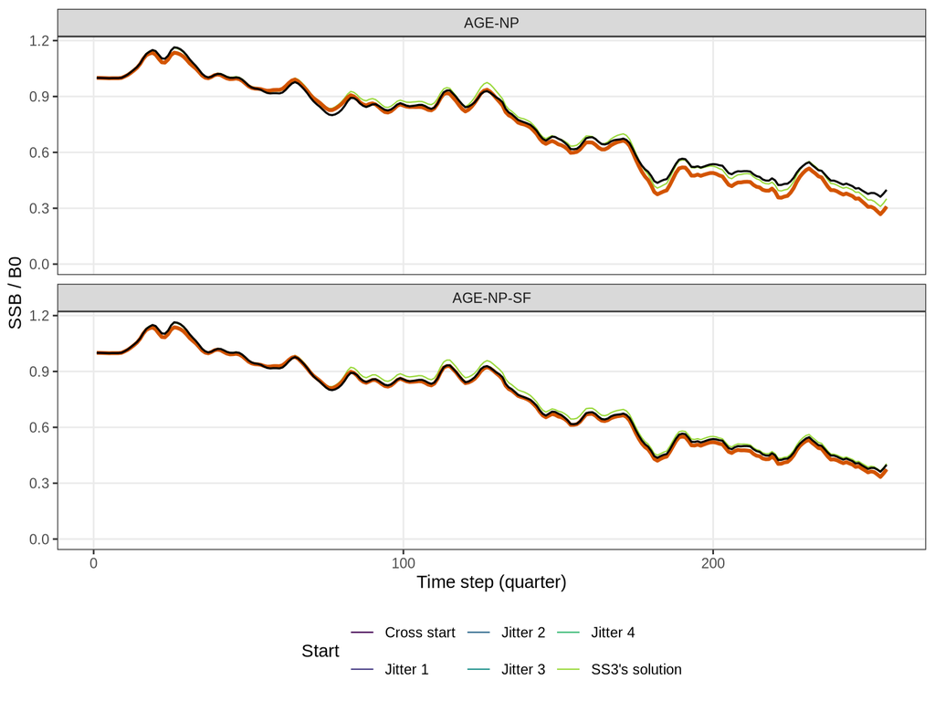

Static depletion of the start-sensitivity fits (thin lines) against the fitted AGE-NP and AGE-NP-SF (thick) and SS3 (black).

```r
st_traj <- do.call(rbind, lapply(seq_len(nrow(st$jobs)), function(i) {
  r <- st$runs[[i]]
  if (!is.null(r$error)) return(NULL)
  data.frame(ts = seq_len(n_ts), dep = r$static_dep, model = st$jobs$model[i],
             start = start_lab[[st$jobs$start[i]]])
}))
fit_traj <- do.call(rbind, lapply(names(st$reference), function(nm)
  data.frame(ts = seq_len(n_ts), dep = st$reference[[nm]]$static_dep, model = nm)))
ss3_traj <- do.call(rbind, lapply(names(st$reference), function(nm)
  data.frame(ts = ref$ss3$trajectory$ts, dep = ref$ss3$trajectory$static_dep, model = nm)))
ggplot() +
  geom_line(data = st_traj, aes(ts, dep, colour = start), linewidth = 0.4) +
  geom_line(data = fit_traj, aes(ts, dep), colour = series_col[["opal AGE-NP-SF"]],
            linewidth = 1.1) +
  geom_line(data = ss3_traj, aes(ts, dep), colour = "black", linewidth = 0.6) +
  facet_wrap(~ model, ncol = 1,
             labeller = as_labeller(c(S1 = "AGE-NP", S2 = "AGE-NP-SF"))) +
  scale_colour_viridis_d(name = "Start", end = 0.85) +
  expand_limits(y = 0) +
  labs(x = "Time step (quarter)", y = "SSB / B0")
```

```r
ss3_row <- st_tab[st_tab$start == "SS3's solution", ]
```

From SS3’s solution, both AGE-NP and AGE-NP-SF stop at an optimum 20.9–22.0 likelihood units worse than the fits started from AGE’s estimates, with B0 0.96–1.02 × SS3’s. That optimum is close to SS3 in stock size, but opal’s data fit prefers the other. The jittered starts show how stable the fitted optimum is: those that return to it (objective difference near 0) give the same stock status. The likelihood surface without priors has more than one optimum, so a comparison of stock size with SS3 depends on where each model starts.

# Selectivity

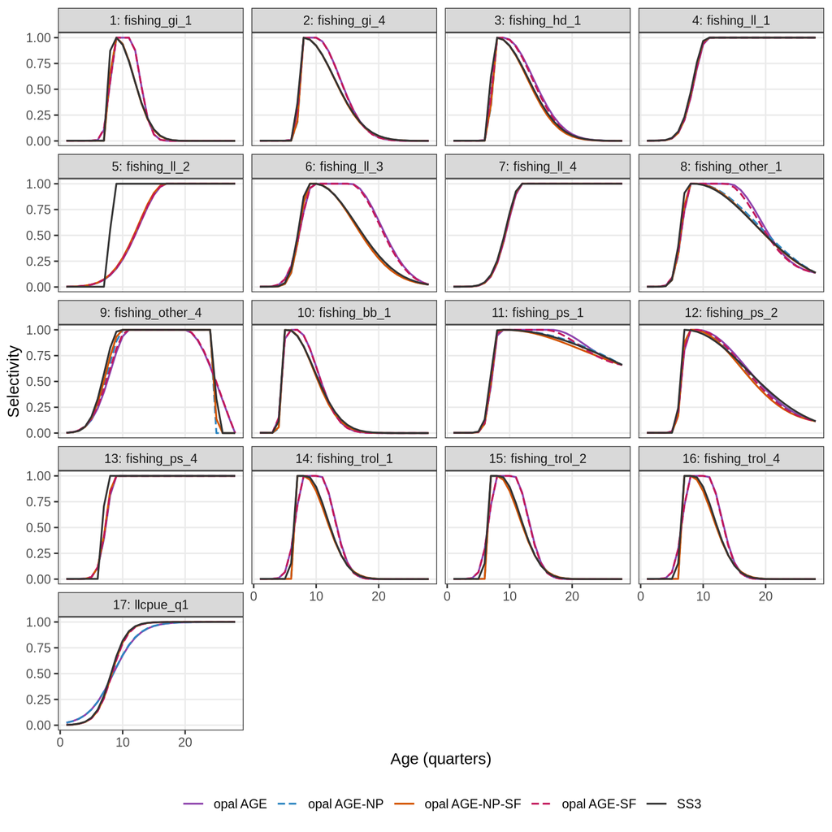

Selectivity-at-age: SS3, AGE, and the fits AGE-NP, AGE-NP-SF and AGE-SF.

```r
sel_series <- c("opal AGE", "opal AGE-NP", "opal AGE-NP-SF",
                "opal AGE-SF")
sa <- rbind(
  data.frame(ref$ss3$sel_age, series = "SS3"),
  do.call(rbind, lapply(sel_series, function(nm) data.frame(fits[[nm]]$sel_age, series = nm))))
sa$series <- factor(sa$series, names(series_col))
ggplot(sa[sa$fishery <= 17, ], aes(age, sel, colour = series, linetype = series)) +
  geom_line(linewidth = 0.6) +
  facet_wrap(~ fishery, ncol = 4, labeller = as_labeller(fleet_name)) +
  scale_series +
  labs(x = "Age (quarters)", y = "Selectivity")
```

```r
a50 <- function(sa) {
  s <- sa[sa$fishery == 17, ]
  stats::approx(s$sel, s$age, 0.5, ties = "ordered")$y
}
knitr::kable(data.frame(
  model = c("SS3", sel_series),
  a50 = c(a50(ref$ss3$sel_age), vapply(sel_series, function(nm) a50(fits[[nm]]$sel_age),
                                       numeric(1), USE.NAMES = FALSE))),
  digits = 2, col.names = c("Model", "Index: age at 50% selectivity (quarters)"))
```

| Model | Index: age at 50% selectivity (quarters) |
| --- | --- |
| SS3 | 8.14 |
| opal AGE | 8.50 |
| opal AGE-NP | 8.47 |
| opal AGE-NP-SF | 8.28 |
| opal AGE-SF | 8.32 |

Fisheries 15 and 16 mirror 14, and panel 17 stands for all four quarterly index series. Without the size compositions (AGE, AGE-NP), the index selectivity is informed only by the CPUE trend. With them (AGE-NP-SF, AGE-SF) its age at 50% selectivity moves towards SS3’s. SS3’s estimate sits at its lower bound of 8 quarters, which opal does not impose.

# Fits to the data

## Index size compositions

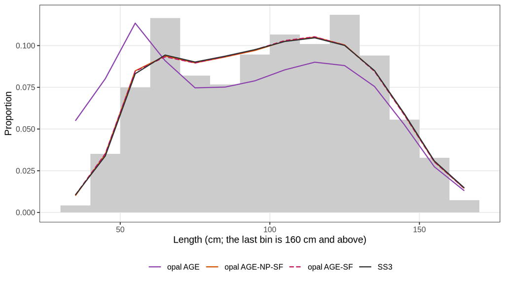

Index size compositions aggregated over all observations, weighted by sample size: observed (bars), SS3’s expected values, AGE (not fitted to them), AGE-NP-SF and AGE-SF.

```r
agg_sf <- function(p, v) {
  a <- tapply(p[[v]] * p$nsamp, p$bin, sum)
  data.frame(bin = as.numeric(names(a)), value = as.numeric(a / sum(a)))
}
p_s2 <- sf_pred("S2")
p_a <- sf_pred("A_ss3_S2")
p_s3 <- sf_pred("S3")
obs_sf <- agg_sf(p_s2, "obs")
lines_sf <- rbind(data.frame(agg_sf(p_s2, "expected"), series = "SS3"),
                  data.frame(agg_sf(p_a, "predicted"), series = "opal AGE"),
                  data.frame(agg_sf(p_s2, "predicted"), series = "opal AGE-NP-SF"),
                  data.frame(agg_sf(p_s3, "predicted"), series = "opal AGE-SF"))
lines_sf$series <- factor(lines_sf$series, names(series_col))
ggplot() +
  geom_col(data = obs_sf, aes(bin + 5, value), fill = "grey80", width = 10) +
  geom_line(data = lines_sf, aes(bin + 5, value, colour = series, linetype = series),
            linewidth = 0.6) +
  scale_series +
  labs(x = "Length (cm; the last bin is 160 cm and above)", y = "Proportion")
```

```r
knitr::kable(data.frame(
  model = c("SS3", "opal AGE (not fitted to them)", "opal AGE-NP-SF", "opal AGE-SF"),
  like = c(ss3_like(p_s2$obs, p_s2$expected, p_s2$nsamp),
           ss3_like(p_a$obs, p_a$predicted, p_a$nsamp),
           ss3_like(p_s2$obs, p_s2$predicted, p_s2$nsamp),
           ss3_like(p_s3$obs, p_s3$predicted, p_s3$nsamp))),
  digits = 1, col.names = c("Model", "SS3-style likelihood of the index size compositions"))
```

| Model | SS3-style likelihood of the index size compositions |
| --- | --- |
| SS3 | 1067.5 |
| opal AGE (not fitted to them) | 1205.3 |
| opal AGE-NP-SF | 1066.7 |
| opal AGE-SF | 1067.7 |

## Index and length compositions

```r
rmse <- function(o, p) sqrt(mean((log(o) - log(p))^2))
cp <- d$cpue_data
lf_change <- function(nm) sum(fits[[nm]]$lf_nll_f[as.character(d$lf_fishery_f)]) -
  sum(m$A_ss3$lf_nll_f[as.character(d$lf_fishery_f)])
knitr::kable(data.frame(
  model = c(names(fits), "SS3"),
  rmse = c(vapply(fits, function(x) rmse(cp$value, x$cpue$pred), numeric(1), USE.NAMES = FALSE),
           rmse(ref$ss3$cpue$obs, ref$ss3$cpue$expected)),
  lf = c(NA, 0, lf_change("opal AGE-NP"), lf_change("opal AGE-NP-SF"),
         lf_change("opal AGE-SF"), NA)),
  digits = c(0, 4, 1),
  col.names = c("Model", "RMSE of log index residuals", "Length comps NLL − AGE"))
```

| Model | RMSE of log index residuals | Length comps NLL − AGE |
| --- | --- | --- |
| opal C2 (length) | 0.0621 | — |
| opal AGE | 0.0617 | 0.0 |
| opal AGE-NP | 0.0615 | -6.5 |
| opal AGE-NP-SF | 0.0640 | 4.5 |
| opal AGE-SF | 0.0642 | 11.1 |
| SS3 | 0.0646 | — |

# Stock status

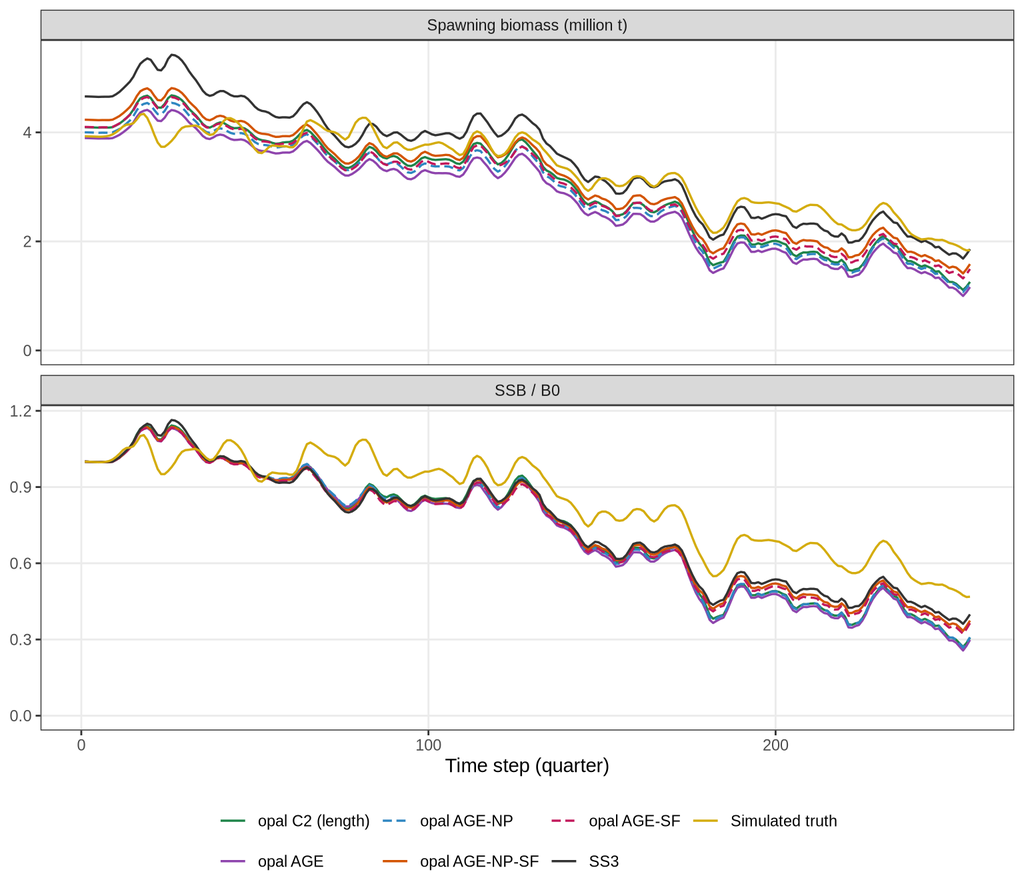

Spawning biomass (top) and static depletion SSB / B0 (bottom) of each fit, SS3 and the simulated truth.

```r
traj <- rbind(
  do.call(rbind, lapply(names(fits), function(nm) data.frame(fits[[nm]]$trajectory, series = nm))),
  data.frame(ref$ss3$trajectory, series = "SS3"),
  data.frame(ref$truth$trajectory, series = "Simulated truth"))
traj$series <- factor(traj$series, names(series_col))
long <- rbind(data.frame(ts = traj$ts, series = traj$series, value = traj$ssb / 1e6,
                         panel = "Spawning biomass (million t)"),
              data.frame(ts = traj$ts, series = traj$series, value = traj$static_dep,
                         panel = "SSB / B0"))
ggplot(long, aes(ts, value, colour = series, linetype = series)) +
  geom_line(linewidth = 0.6) +
  facet_wrap(~ panel, ncol = 1, scales = "free_y") +
  expand_limits(y = 0) +
  scale_series +
  labs(x = "Time step (quarter)", y = NULL)
```

```r
ss3_tr <- ref$ss3$trajectory
vs_ss3 <- function(tr) {
  mm <- merge(tr, ss3_tr, by = "ts")
  c(mean_pct = mean(abs(100 * (mm$ssb.x / mm$ssb.y - 1))),
    max_dep = max(abs(mm$static_dep.x - mm$static_dep.y)))
}
status <- do.call(rbind, lapply(names(fits), function(nm) {
  x <- fits[[nm]]
  data.frame(model = nm, B0_ss3 = x$B0 / ref$ss3$ssb0, B0_truth = x$B0 / ref$truth$b0,
             dep = last(x$trajectory, "static_dep"), t(vs_ss3(x$trajectory)))
}))
status <- rbind(status,
  data.frame(model = "SS3", B0_ss3 = 1, B0_truth = ref$ss3$ssb0 / ref$truth$b0,
             dep = last(ss3_tr, "static_dep"), mean_pct = NA, max_dep = NA),
  data.frame(model = "Simulated truth", B0_ss3 = ref$truth$b0 / ref$ss3$ssb0, B0_truth = 1,
             dep = last(ref$truth$trajectory, "static_dep"), mean_pct = NA, max_dep = NA))
knitr::kable(status, digits = c(0, 3, 3, 3, 1, 3), row.names = FALSE,
             col.names = c("Model", "B0 / SS3 B0", "B0 / true B0", "Terminal SSB / B0",
                           "SSB mean |% diff| from SS3", "Max |depletion diff| from SS3"))
```

| Model | B0 / SS3 B0 | B0 / true B0 | Terminal SSB / B0 | SSB mean \|% diff\| from SS3 | Max \|depletion diff\| from SS3 |
| --- | --- | --- | --- | --- | --- |
| opal C2 (length) | 0.879 | 1.042 | 0.307 | 15.5 | 0.093 |
| opal AGE | 0.836 | 0.992 | 0.298 | 21.0 | 0.105 |
| opal AGE-NP | 0.859 | 1.018 | 0.309 | 17.8 | 0.094 |
| opal AGE-NP-SF | 0.908 | 1.077 | 0.374 | 10.7 | 0.028 |
| opal AGE-SF | 0.880 | 1.044 | 0.364 | 14.6 | 0.039 |
| SS3 | 1.000 | 1.186 | 0.399 | — | — |
| Simulated truth | 0.843 | 1.000 | 0.468 | — | — |

# Summary

| Fit | Priors | Index size compositions | Selectivity parameters estimated |
| --- | --- | --- | --- |
| AGE | opal defaults | no | all 58 SS3 estimated |
| AGE-NP | off (λ = 0) | no | the identifiable ones |
| AGE-NP-SF | off (λ = 0) | yes (λ = 0.51) | the identifiable ones |
| AGE-SF | opal defaults | yes (λ = 0.51) | all 58 |

```r
dep <- function(nm) last(fits[[nm]]$trajectory, "static_dep")
b0 <- function(nm) fits[[nm]]$B0 / ref$ss3$ssb0
```

- opal now takes the two SS3 settings AGE lacked: SS3’s lambda of 0 on parameter priors (`data$lambdas$prior`), and SS3’s generalised size compositions for the index on their own bins with SS3’s lambda of 0.51 (a second bin scheme through `prep_lf_data()`, weighted by `lf` lambdas). At SS3’s solution, opal’s predictions of those size compositions agree with SS3’s expected values.
- Without priors, 20 selectivity parameters SS3 estimated are not identified, and AGE-NP and AGE-NP-SF hold them at their free estimates, which leaves the objective unchanged. AGE-NP then has a positive-definite Hessian; AGE-NP-SF does not. With the priors kept, AGE-SF passes `opal_check()`.
- From AGE’s estimates, B0 is 0.84 (AGE), 0.86 (AGE-NP), 0.91 (AGE-NP-SF) and 0.88 (AGE-SF) × SS3’s. Terminal depletion is 0.298, 0.309, 0.374 and 0.364, against SS3’s 0.399. The index size compositions move opal closest to SS3, with or without priors (AGE to AGE-SF, or AGE-NP to AGE-NP-SF). Removing the priors changes little at this optimum.
- Started from SS3’s own solution, AGE-NP and AGE-NP-SF stop at an optimum with stock size close to SS3’s, but worse for opal’s likelihood. The remaining gap to SS3 is partly a question of which optimum each model is in, and partly the accepted structural differences (catch and survey timing, four quarterly catchabilities, unconstrained recruitment deviations).

The outputs in this article were computed with opal 0.1.1 (commit fd7efc2) by `data-raw/generate-io-yft-matched-fits.R` and `data-raw/generate-io-yft-vignette-cache.R`. SS3’s size compositions and lambdas were exported by code/rtmb/scripts/06-export-io-yft-sizefreq-for-opal.r in https://github.com/N-DucharmeBarth/wcpfc-bet-single-region.